# Graphs in Python: Boxplots with Multiple Groups of Data *using explicitly defined axes in Matplotlib*

⇦ Back

For this page we will use data from the finals of various Olympic events, available on Wikipedia.

This page functions as a follow-on from Boxplots with One Group of Data.

# 1 Too Simple

If we try to plot multiple datasets (eg the results from more than one Olympic Games) with two groups within each dataset (men and women), things start to become confusing:

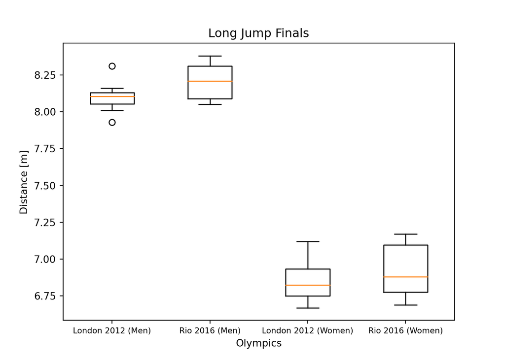

```python
import matplotlib.pyplot as plt
import numpy as np
import pandas as pd

# Results of the long jump finals at two Olympic Games
data = pd.DataFrame({
    'London 2012 (Men)': [8.31, 8.16, 8.12, 8.11, 8.10, 8.07, 8.01, 7.93],
    'Rio 2016 (Men)': [8.38, 8.37, 8.29, 8.25, 8.17, 8.10, 8.06, 8.05],
    'London 2012 (Women)': [7.12, 7.07, 6.89, 6.88, 6.77, 6.76, 6.72, 6.67],
    'Rio 2016 (Women)': [7.17, 7.15, 7.08, 6.95, 6.81, 6.79, 6.74, 6.69]
})

# Plot
ax = plt.axes()
bp = ax.boxplot(
    # A data frame needs to be converted to an array before it can be plotted this way
    np.array(data),
    # You can use the column headings from the data frame as labels
    labels=list(data)
)
# Axis details
ax.set(xlabel='Olympics', ylabel='Distance [m]', title='Long Jump Finals')
ax.tick_params(axis='x', which='major', labelsize=8)
plt.show()
```

# 2 A Better Approach

Try breaking the plots up into groups, clearly showing showing which boxes belong together in order to aid interpretation. This will also allow you to fit more data in:

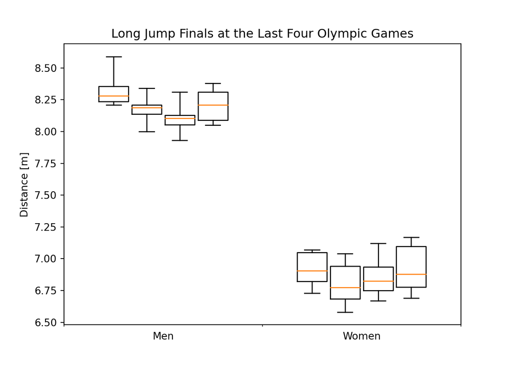

```python
import matplotlib.pyplot as plt
import numpy as np
import pandas as pd

# Results of the long jump finals at four olympic games
athens = pd.DataFrame({
    'Men': [8.59, 8.47, 8.32, 8.31, 8.25, 8.24, 8.23, 8.21],
    'Women': [7.07, 7.05, 7.05, 6.96, 6.85, 6.83, 6.80, 6.73]
})
beijing = pd.DataFrame({
    'Men': [8.34, 8.24, 8.20, 8.19, 8.19, 8.16, 8.07, 8.00],
    'Women': [7.04, 7.03, 6.91, 6.79, 6.76, 6.70, 6.64, 6.58]
})
london = pd.DataFrame({
    'Men': [8.31, 8.16, 8.12, 8.11, 8.10, 8.07, 8.01, 7.93],
    'Women': [7.12, 7.07, 6.89, 6.88, 6.77, 6.76, 6.72, 6.67]
})
rio = pd.DataFrame({
    'Men': [8.38, 8.37, 8.29, 8.25, 8.17, 8.10, 8.06, 8.05],
    'Women': [7.17, 7.15, 7.08, 6.95, 6.81, 6.79, 6.74, 6.69]
})
datasets = [athens, beijing, london, rio]

# Create the plot
ax = plt.axes()
# Set x-positions for boxes
x_pos_range = np.arange(len(datasets)) / (len(datasets) - 1)
x_pos = (x_pos_range * 0.5) + 0.75
# Plot
for i, data in enumerate(datasets):
    bp = ax.boxplot(
        np.array(data), sym='', whis=[0, 100], widths=0.6 / len(datasets),
        labels=list(datasets[0]),
        positions=[x_pos[i] + j * 1 for j in range(len(data.T))]
    )
# Titles
ax.set(
    title='Long Jump Finals at the Last Four Olympic Games',
    ylabel='Distance [m]'
)
# Remove the major x-axis tickmarks
ax.tick_params(axis='x', bottom=False)
# Positions of the x-axis labels
xticks = ax.set_xticks(np.arange(len(list(datasets[0]))) + 1)
# Positions of the minor x-axis tickmarks
xticks = ax.set_xticks(np.arange(len(list(datasets[0])) + 1) + 0.5, minor=True)
# Change the limits of the x-axis
xlim = ax.set_xlim([0.5, len(list(datasets[0])) + 0.5])

plt.show()
```

Note that we could also have used lists-of-lists as the datasets instead of data frames (with some minor changes, eg `data` would not have been transposed and the labels would have needed to be manually coded).

# 3 Colour and Format

A big step towards better communication will be colour-coding the boxes. At the same time we’ll improve the format and size of the plots (see Image Sizes and Latex in Labels for more info):

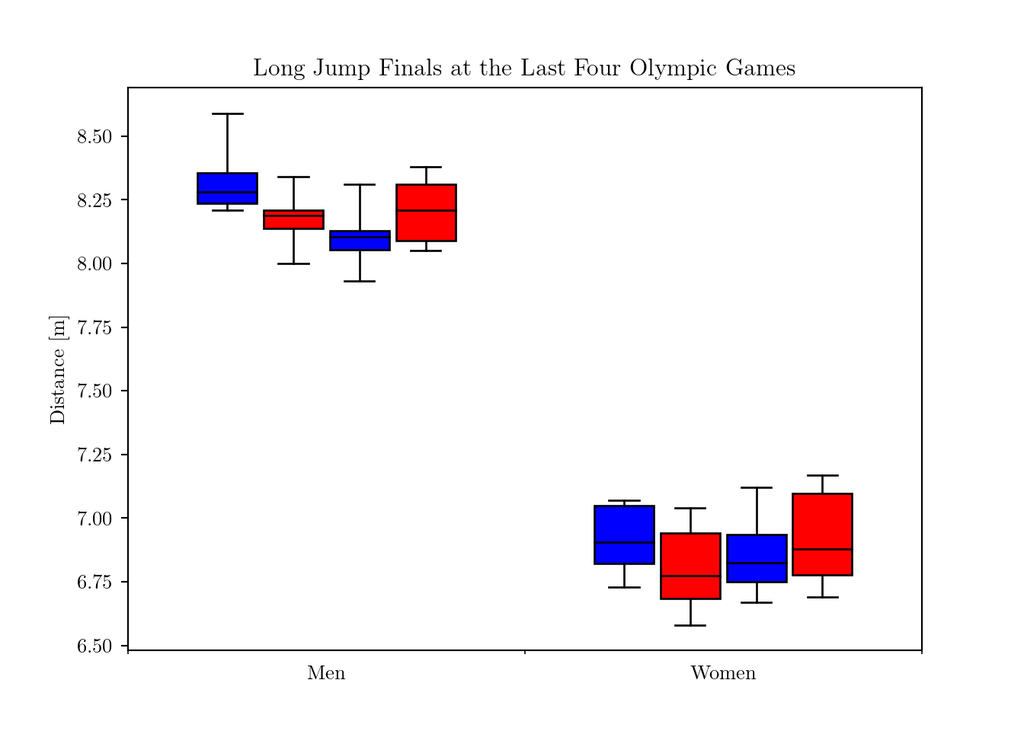

```python
# Settings
x = 6  # Want figures to be A6
plt.rc('figure', figsize=[46.82 * .5**(.5 * x), 33.11 * .5**(.5 * x)])
plt.rc('text', usetex=True)
plt.rc('font', family='serif')

# Define which colours you want to use
colours = ['blue', 'red']

# Create the plot
ax = plt.axes()
# Set x-positions for boxes
x_pos_range = np.arange(len(datasets)) / (len(datasets) - 1)
x_pos = (x_pos_range * 0.5) + 0.75
# Plot
for i, data in enumerate(datasets):
    bp = ax.boxplot(
        np.array(data), sym='', whis=[0, 100], widths=0.6 / len(datasets),
        labels=list(datasets[0]), patch_artist=True,
        positions=[x_pos[i] + j * 1 for j in range(len(data.T))]
    )
    # Fill the boxes with colours (requires patch_artist=True)
    k = i % len(colours)
    for box in bp['boxes']:
        box.set(facecolor=colours[k])
    # Make the median lines more visible
    plt.setp(bp['medians'], color='black')

# Axis details
details = ax.set(
    title='Long Jump Finals at the Last Four Olympic Games',
    ylabel='Distance [m]'
)
ax.tick_params(axis='x', bottom=False)
xticks = ax.set_xticks(np.arange(len(list(datasets[0]))) + 1)
xticks = ax.set_xticks(np.arange(len(list(datasets[0])) + 1) + 0.5, minor=True)
xlim = ax.set_xlim([0.5, len(list(datasets[0])) + 0.5])

plt.show()
```

The one glaring omission is that we still need to show *which* Olympics each set of data comes from…

# 4 Legend

Adding a legend will clarify what data belongs to what group.

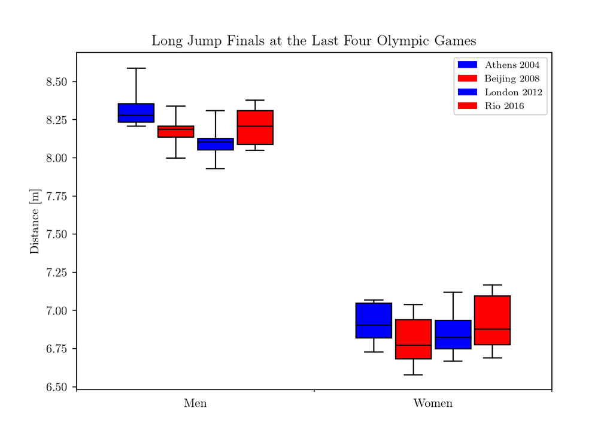

```python
from matplotlib.patches import Patch

# Define which colours you want to use
colours = ['blue', 'red']
# Define the groups
groups = ['Athens 2004', 'Beijing 2008', 'London 2012', 'Rio 2016']

# Legend
legend_elements = []
for i in range(len(datasets)):
    j = i % len(groups)
    k = i % len(colours)
    legend_elements.append(Patch(facecolor=colours[k], label=groups[j]))
ax.legend(handles=legend_elements, fontsize=8)
```

# 5 Annotate the Median Values

The median value of each boxplot can be shown directly on the plot using annotations. Note that if there are too many groups when doing this the annotations might start to overlap, so we’ll drop down to just two for this example.

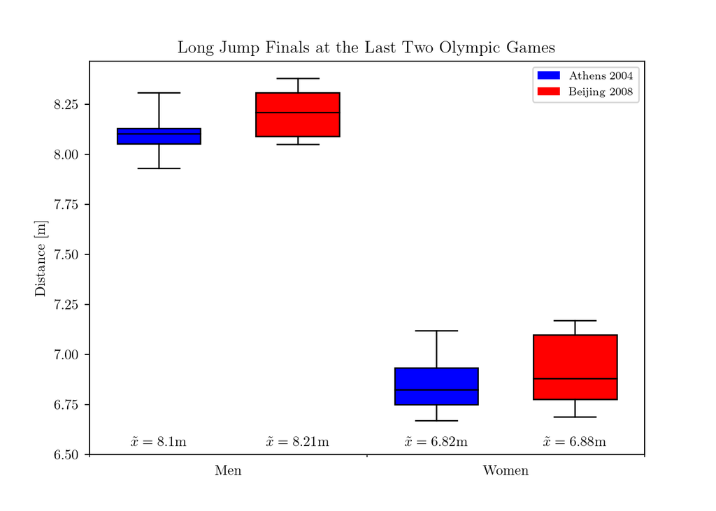

```python
datasets = [london, rio]

# Define which colours you want to use
colours = ['blue', 'red']
# Define the groups
groups = ['Athens 2004', 'Beijing 2008', 'London 2012', 'Rio 2016']

# Get the max of the dataset
all_maximums = [d.max(axis=1).values for d in datasets]
dataset_maximums = [max(m) for m in all_maximums]
y_max = max(dataset_maximums)
# Get the min of the dataset
all_minimums = [d.min(axis=1).values for d in datasets]
dataset_minimums = [min(m) for m in all_minimums]
y_min = min(dataset_minimums)
# Calculate the y-axis range
y_range = y_max - y_min

# Create the plot
ax = plt.axes()
# Set x-positions for boxes
x_pos_range = np.arange(len(datasets)) / (len(datasets) - 1)
x_pos = (x_pos_range * 0.5) + 0.75
# Plot
for i, data in enumerate(datasets):
    positions = [x_pos[i] + j * 1 for j in range(len(data.T))]
    bp = ax.boxplot(
        np.array(data), sym='', whis=[0, 100], widths=0.6 / len(datasets),
        labels=list(datasets[0]), patch_artist=True,
        positions=positions
    )
    # Fill the boxes with colours (requires patch_artist=True)
    k = i % len(colours)
    for box in bp['boxes']:
        box.set(facecolor=colours[k])
    # Make the median lines more visible
    plt.setp(bp['medians'], color='black')

    # Get the samples' medians
    medians = [bp['medians'][j].get_ydata()[0] for j in range(len(data.T))]
    medians = [str(round(s, 2)) for s in medians]
    # Increase the height of the plot by 5% to fit the labels
    ax.set_ylim([y_min - 0.1 * y_range, y_max + 0.05 * y_range])
    # Set the y-positions for the labels
    y_pos = y_min - 0.075 * y_range
    for tick, label in zip(range(len(data.T)), ax.get_xticklabels()):
        k = tick % 2
        ax.text(
            positions[tick], y_pos, r'$\tilde{x} =' + fr' {medians[tick]}$m',
            horizontalalignment='center', size='medium'
        )

# Axis details
details = ax.set(
    title='Long Jump Finals at the Last Two Olympic Games',
    ylabel='Distance [m]'
)
ax.tick_params(axis='x', bottom=False)
xticks = ax.set_xticks(np.arange(len(list(datasets[0]))) + 1)
xticks = ax.set_xticks(np.arange(len(list(datasets[0])) + 1) + 0.5, minor=True)
xlim = ax.set_xlim([0.5, len(list(datasets[0])) + 0.5])
# Legend
legend_elements = []
for i in range(len(datasets)):
    j = i % len(groups)
    k = i % len(colours)
    legend_elements.append(Patch(facecolor=colours[k], label=groups[j]))
ax.legend(handles=legend_elements, fontsize=8)

plt.show()
```

# 6 Adjusting the Plot Area

When things start getting busier you’ll want to have the legend positioned *outside* the plot itself. This will require you to edit the amount of white space between the edge of the graph and the edge of the image, and this can be done in the `fig.add_axes()` function:

- The function `fig.add_axes()` takes a list of four numbers: the amount of white space to the left and below the plot and the plot’s width and height
- These four numbers are expressed as ‘proportion of the image’; ie if width is 0.8 then the width of the plot will be 80% of the width of the image
- The default values are `[0.125, 0.11, 0.775, 0.77]`, meaning that the white space to the left of the plot is equal to 12.5% of the width of the image, the white space at the bottom of the image is 11% of the image’s height, etc

With regards to the legend, its location cannot be finely adjusted when you use `ax.legend()` so it cannot be moved outside the plot as things stand. However, we can use the more basic function `plt.gca().legend()` (where `gca` stands for ‘get current axis’) to isolate just the legend of the current set of axes in order to edit its hidden attributes. Specifically, we can use the `bbox_to_anchor=()` keyword argument to define its position, so by setting this to $(1, 0.5)$ the legend will be placed at $x = 1$ (ie outside the plot, to the right of it) and at $y = 0.5$ (ie halfway up the plot).

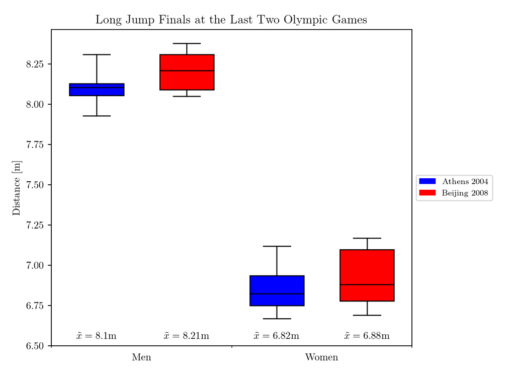

```python
# Create the plot
# plt.axes([left, bottom, width, height])
# Default = [0.125, 0.11, 0.775, 0.77]
ax = plt.axes([0.1, 0.06, 0.7, 0.86])
# Set x-positions for boxes
x_pos_range = np.arange(len(datasets)) / (len(datasets) - 1)
x_pos = (x_pos_range * 0.5) + 0.75
# Plot
for i, data in enumerate(datasets):
    positions = [x_pos[i] + j * 1 for j in range(len(data.T))]
    bp = ax.boxplot(
        np.array(data), sym='', whis=[0, 100], widths=0.6 / len(datasets),
        labels=list(datasets[0]), patch_artist=True,
        positions=positions
    )
    # Fill the boxes with colours (requires patch_artist=True)
    k = i % len(colours)
    for box in bp['boxes']:
        box.set(facecolor=colours[k])
    # Make the median lines more visible
    plt.setp(bp['medians'], color='black')

    # Get the samples' medians
    medians = [bp['medians'][j].get_ydata()[0] for j in range(len(data.T))]
    medians = [str(round(s, 2)) for s in medians]
    # Increase the height of the plot by 5% to fit the labels
    ax.set_ylim([y_min - 0.1 * y_range, y_max + 0.05 * y_range])
    # Set the y-positions for the labels
    y_pos = y_min - 0.075 * y_range
    for tick, label in zip(range(len(data.T)), ax.get_xticklabels()):
        k = tick % 2
        ax.text(
            positions[tick], y_pos, r'$\tilde{x} =' + fr' {medians[tick]}$m',
            horizontalalignment='center', size='medium'
        )

# Axis details
details = ax.set(
    title='Long Jump Finals at the Last Two Olympic Games',
    ylabel='Distance [m]'
)
ax.tick_params(axis='x', bottom=False)
xticks = ax.set_xticks(np.arange(len(list(datasets[0]))) + 1)
xticks = ax.set_xticks(np.arange(len(list(datasets[0])) + 1) + 0.5, minor=True)
xlim = ax.set_xlim([0.5, len(list(datasets[0])) + 0.5])
# Legend
legend_elements = []
for i in range(len(datasets)):
    j = i % len(groups)
    k = i % len(colours)
    legend_elements.append(Patch(facecolor=colours[k], label=groups[j]))
plt.gca().legend(
    legend_elements, groups,
    fontsize=8, loc='center left', bbox_to_anchor=(1, 0.5)
)

plt.show()
```

# 7 Edit the Background and Gridlines

A background can help make the plot look more professional and gridlines can aid in interpretation.

- A background colour is set with `ax.set_facecolor()`. A specific colour can be set (eg ‘red’, ‘blue’, etc) while a number between 0 and 1 in string format (eg ‘0.9’) will invoke a shade of grey (‘0’ being black, ‘1’ being white)
- Show the major axis gridlines using `plt.grid(True)`
- Plot horizontal lines to aid in interpretation using `ax.axhline()`

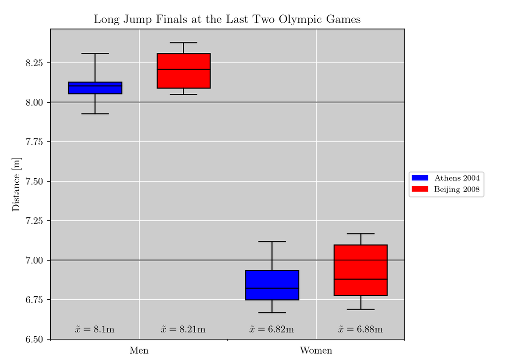

```python
# Background
ax.set_facecolor('0.8')
plt.grid(True, color='white')
ax.axhline(7, color='black', alpha=0.4)
ax.axhline(8, color='black', alpha=0.4)
```

# 8 Swapping Groups and Categories

The method of plotting we have been using is robust to the number of datasets and groups that are used, so if we wanted to add in more data and swap things around it shouldn’t be too much of a problem:

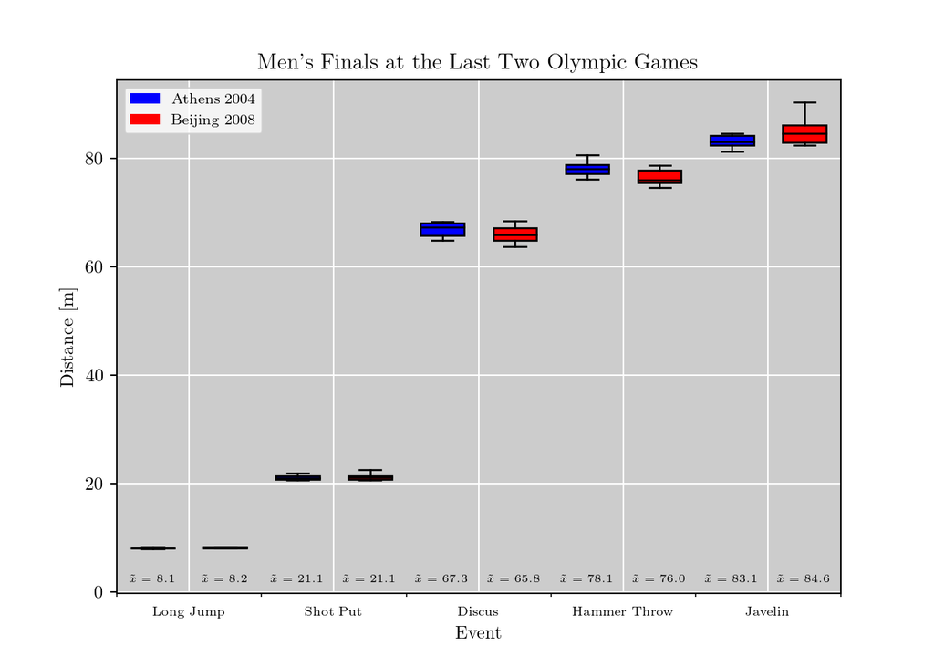

```python
london = pd.DataFrame({
    'Long Jump': [8.31, 8.16, 8.12, 8.11, 8.10, 8.07, 8.01, 7.93],
    'Shot Put': [21.89, 21.86, 21.23, 21.19, 20.93, 20.84, 20.71, 20.69],
    'Discus': [68.27, 68.18, 68.03, 67.38, 67.19, 65.85, 65.56, 64.79],
    'Hammer Throw': [80.59, 79.36, 78.71, 78.25, 77.86, 77.17, 77.10, 76.07],
    'Javelin': [84.58, 84.51, 84.12, 83.34, 82.80, 82.63, 81.91, 81.21]
})
rio = pd.DataFrame({
    'Long Jump': [8.38, 8.37, 8.29, 8.25, 8.17, 8.10, 8.06, 8.05],
    'Shot Put': [22.52, 21.78, 21.36, 21.20, 21.02, 20.72, 20.64, 20.64],
    'Discus': [68.37, 67.55, 67.05, 66.58, 65.10, 64.95, 64.50, 63.72],
    'Hammer Throw': [78.68, 77.79, 77.73, 76.05, 75.97, 75.46, 75.28, 74.61],
    'Javelin': [90.30, 88.24, 85.38, 85.32, 83.95, 83.05, 82.51, 82.42]
})
datasets = [london, rio]
# Define which colours you want to use
colours = ['blue', 'red']
# Define the groups
groups = ['Athens 2004', 'Beijing 2008', 'London 2012', 'Rio 2016']

# Get the max of the dataset
all_maximums = [d.max(axis=1).values for d in datasets]
dataset_maximums = [max(m) for m in all_maximums]
y_max = max(dataset_maximums)
# Get the min of the dataset
all_minimums = [d.min(axis=1).values for d in datasets]
dataset_minimums = [min(m) for m in all_minimums]
y_min = min(dataset_minimums)
# Calculate the y-axis range
y_range = y_max - y_min

# Create the plot
# plt.axes([left, bottom, width, height])
# Default = [0.125, 0.11, 0.775, 0.77]
ax = plt.axes()
# Set x-positions for boxes
x_pos_range = np.arange(len(datasets)) / (len(datasets) - 1)
x_pos = (x_pos_range * 0.5) + 0.75
# Plot
for i, data in enumerate(datasets):
    positions = [x_pos[i] + j * 1 for j in range(len(data.T))]
    bp = ax.boxplot(
        np.array(data), sym='', whis=[0, 100], widths=0.6 / len(datasets),
        labels=list(datasets[0]), patch_artist=True,
        positions=positions
    )
    # Fill the boxes with colours (requires patch_artist=True)
    k = i % len(colours)
    for box in bp['boxes']:
        box.set(facecolor=colours[k])
    # Make the median lines more visible
    plt.setp(bp['medians'], color='black')

    # Get the samples' medians
    medians = [bp['medians'][j].get_ydata()[0] for j in range(len(data.T))]
    medians = [str(round(s, 1)) for s in medians]
    # Increase the height of the plot by 5% to fit the labels
    ax.set_ylim([y_min - 0.1 * y_range, y_max + 0.05 * y_range])
    # Set the y-positions for the labels
    y_pos = y_min - 0.075 * y_range
    for tick, label in zip(range(len(data.T)), ax.get_xticklabels()):
        k = tick % 2
        ax.text(
            positions[tick], y_pos, r'$\tilde{x}=' + fr'{medians[tick]}$',
            horizontalalignment='center', size='xx-small'
        )
# Axis details
details = ax.set(
    title="Men's Finals at the Last Two Olympic Games",
    ylabel='Distance [m]'
)
ax.set_xlabel('Event')
ax.tick_params(axis='x', bottom=False)
xticks = ax.set_xticks(np.arange(len(list(datasets[0]))) + 1)
xticks = ax.set_xticks(np.arange(len(list(datasets[0])) + 1) + 0.5, minor=True)
xlim = ax.set_xlim([0.5, len(list(datasets[0])) + 0.5])
for tick in ax.xaxis.get_major_ticks():
    tick.label.set_fontsize(7)
# Legend
legend_elements = []
for i in range(len(datasets)):
    j = i % len(groups)
    k = i % len(colours)
    legend_elements.append(Patch(facecolor=colours[k], label=groups[j]))
ax.legend(handles=legend_elements, fontsize=8)
# Background
ax.set_facecolor('0.8')
plt.grid(True, color='white')

plt.show()
```

# 9 Subplots

The easiest way to plots multiple graphs that all have the same format is to create a function and call that repeatedly on each dataset. Some changes do need to be made, however:

- Increase the size of the image so that all plots can fit onto it. Generally speaking, six plots can fit on an A4 page.
- Subplots need to be created using `fig, axes = plt.subplots(nrows, ncols)`
- Change the spacing between graphs and the edges of the image with `fig.subplots_adjust()`
- Iterate though the datasets you want to plot using `for i, ax in enumerate(axes.flat):`
- Certain elements that change from plot-to-plot now become arguments of the function:
  - The datasets themselves
  - The axes themselves
  - The plot titles

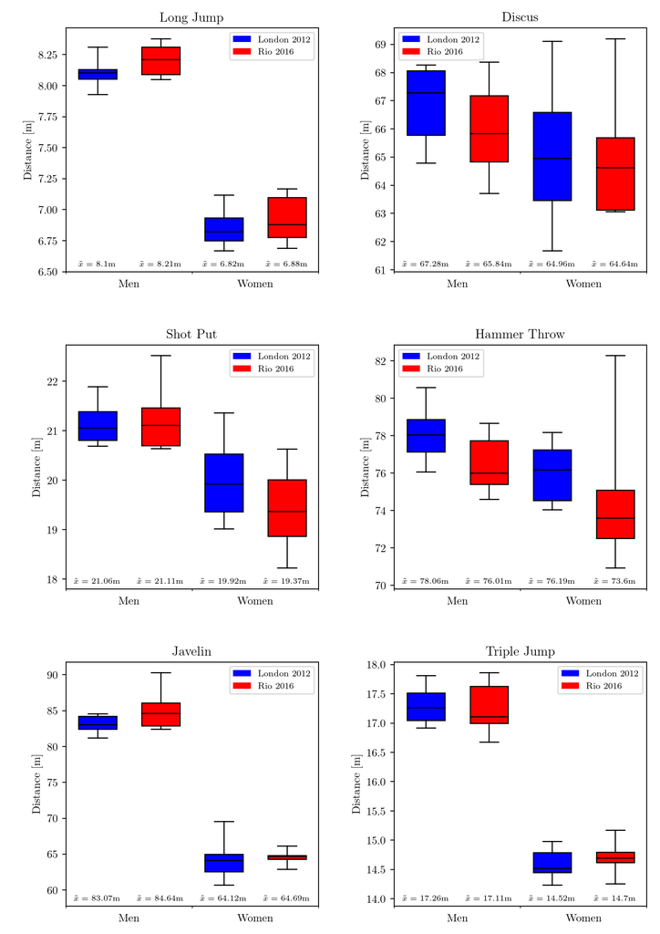

```python
def plot_boxplots(datasets, colours, groups, ax, title):
    # Get the max of the dataset
    all_maximums = [d.max(axis=1).values for d in datasets]
    dataset_maximums = [max(m) for m in all_maximums]
    y_max = max(dataset_maximums)
    # Get the min of the dataset
    all_minimums = [d.min(axis=1).values for d in datasets]
    dataset_minimums = [min(m) for m in all_minimums]
    y_min = min(dataset_minimums)
    # Calculate the y-axis range
    y_range = y_max - y_min

    # Set x-positions for boxes
    x_pos_range = np.arange(len(datasets)) / (len(datasets) - 1)
    x_pos = (x_pos_range * 0.5) + 0.75
    # Create the plot
    for i, data in enumerate(datasets):
        positions = [x_pos[i] + j * 1 for j in range(len(data.T))]
        bp = ax.boxplot(
            np.array(data), sym='', whis=[0, 100], widths=0.6 / len(datasets),
            labels=list(datasets[0]), patch_artist=True,
            positions=positions
        )
        # Fill the boxes with colours (requires patch_artist=True)
        k = i % len(colours)
        for box in bp['boxes']:
            box.set(facecolor=colours[k])
        # Make the median lines more visible
        plt.setp(bp['medians'], color='black')

        # Get the samples' medians
        medians = [bp['medians'][j].get_ydata()[0] for j in range(len(data.T))]
        medians = [str(round(s, 2)) for s in medians]
        # Increase the height of the plot by 5% to fit the labels
        ax.set_ylim([y_min - 0.1 * y_range, y_max + 0.05 * y_range])
        # Set the y-positions for the labels
        y_pos = y_min - 0.075 * y_range
        for tick, label in zip(range(len(data.T)), ax.get_xticklabels()):
            k = tick % 2
            ax.text(
                positions[tick], y_pos, r'$\tilde{x}=' + fr'{medians[tick]}$m',
                horizontalalignment='center', size='x-small'
            )
    # Axis details
    ax.set(title=title, ylabel='Distance [m]')
    ax.tick_params(axis='x', bottom=False)
    ax.set_xticks(np.arange(len(list(datasets[0]))) + 1)
    ax.set_xticks(np.arange(len(list(datasets[0])) + 1) + 0.5, minor=True)
    ax.set_xlim([0.5, len(list(datasets[0])) + 0.5])

    # Legend
    legend_elements = []
    for i in range(len(datasets)):
        j = i % len(groups)
        k = i % len(colours)
        legend_elements.append(Patch(facecolor=colours[k], label=groups[j]))
    ax.legend(handles=legend_elements, fontsize=8)

# Make figures A4 in size
A = 4
plt.rc('figure', figsize=[33.11 * .5**(.5 * A), 46.82 * .5**(.5 * A)])
# Use Latex
plt.rc('text', usetex=True)
plt.rc('font', family='serif')

# Call function
fig, axes = plt.subplots(3, 2)
fig.subplots_adjust(
    left=0.1, right=0.98, top=0.97, bottom=0.03, wspace=0.3, hspace=0.3
)
for i, ax in enumerate(axes.flat):
    plot_boxplots(datasets[i], colours, groups[i], ax, title[i])

plt.show()
```

⇦ Back